# Analysis of Vox's Gun Related Deaths

1. Vox, Source - Gun Related Deaths

https://www.vox.com/a/mass-shootings-america-sandy-hook-gun-violence

1. This article by Vox, was intended for general public readers and also anyone interested in the topic of firearm legislation, and mass shootings. The link above presents the article which displays several graphs and charts that correlate to mass shootings in the United States; while the graphics are well designed, there is an underlying political goal of winning your mind on gun legislation. It is well known that VOX is a liberal-leaning media company.

## COMPONENTS OF MISLEADING VISUALS:

### 1. Hiding Relevant Data:

The misleading scatter plot’s labels:

X-Axis Guns per 100 people,

Y-Axis is: Gun-related deaths per 100,000 people.

With a quick glance, you would be able to deduce from the chart alone that the United States itself stands out and is an outlier without needing any metric. Infact, the United States was literally off the chart. Here, Vox was hiding more data, of other countries in the IDX of 0.75 or higher, and handpicked countries that specifically had low Gun Deaths per 100,000 people. With the USA being a country that allows gun ownership and has higher deaths than the handpicked countries, this allowed the chart to be manipulated for Vox’s needs.

### 2. Displaying Too Much Data to Obscure Reality:

Web Developers become more advanced and add new features to websites and charts as technology progresses. But here, as we attempt to scroll to the next graphic charts that Vox has created, we see two single sentences that slide up, prior to moving on to the next media.

"America is a big outlier among developed countries when it comes to gun deaths — in large part because it has so many guns, making it easy to carry out an act of violence."

"Studies have linked stricter gun laws to fewer gun deaths. But the US has the weakest gun laws in the developed world."

Because of the annotation, one can assume from a quick glance that the United States is an outlier, with x3 the amount of gun deaths, in this chart due to the amount of guns in combination with weak gun legislation.

Curious as I was, I decided to explore the data from the same sources Vox had used (Gunpolicy.org , United Nations Development Programme). I created two charts, from Gunpolicy.org, handpicking countries that had a 0.75 or higher HDI as the X-Axis. I also set the Y-Axis as the Rate of Gun Deaths per 100,000 people. The other chart had the same countries as the X-Axis, while the Y-Axis was the rate of civilian possession per 100 population.

The countries that I handpicked were:

Country (Gun Deaths per 100k, Guns per 100 People)

Venezuela (49.73, 18.5)

Guatemala (25.48,12.1)

Brazil (22, 8.3)

Georgia (15.56, 10.1)

United States (12.21, 120.5)

Canada (2, 34.7)

Here is the link to the chart with Rate of All Gun Deaths:

https://tinyurl.com/itdsgraph2

[figure not shown]

Here is the link to the chart with Gun Ownership per 100 Population:

https://tinyurl.com/itdsgraph3

[figure not shown]

Finally, I create a scatter plot using those specific hand picked countries.

https://tinyurl.com/itdsscatterplot

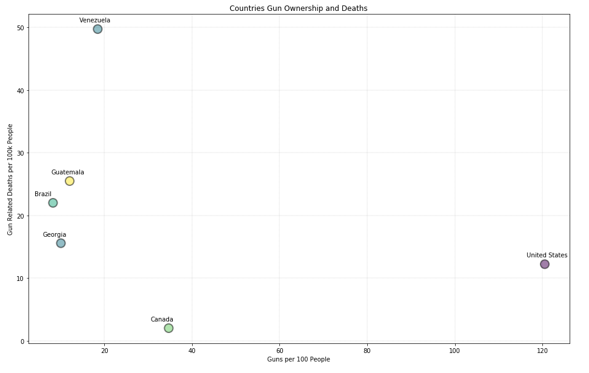

Quickly looking at the third chart I provided above, what would you deduce from that?

```python
import pandas as pd
import numpy as np
import matplotlib.pyplot as plt
```

```python
country = ['Venezuela','Guatemala','Brazil','Georgia','United States','Canada']
deaths = [49.73, 25.48, 22, 15.56, 12.21, 2]
ownership = [18.5, 12.1, 8.3, 10.1, 120.5, 34.7]

dict = {'country':country, 'deaths':deaths, 'ownership':ownership}
```

```python
df = pd.DataFrame(dict)
df = df.set_index('country')
df
```

| country | deaths | ownership |
| --- | --- | --- |
| Venezuela | 49.73 | 18.5 |
| Guatemala | 25.48 | 12.1 |
| Brazil | 22.00 | 8.3 |
| Georgia | 15.56 | 10.1 |
| United States | 12.21 | 120.5 |
| Canada | 2.00 | 34.7 |

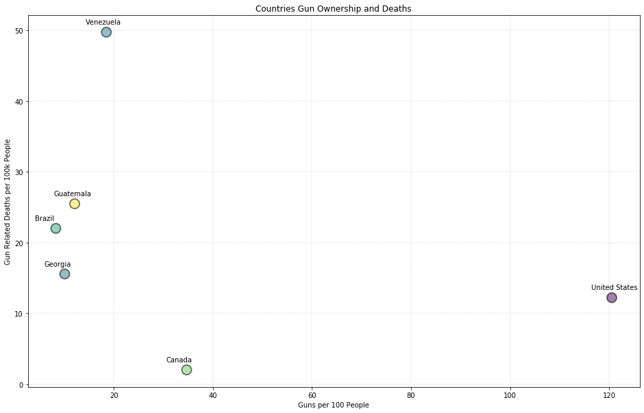

```python
labels = country
x = ownership
y = deaths

rng = np.random.RandomState(0)                     # randomizer with numpy
colors = rng.rand(6)                               # Randomizes 6 colors for the 6 Countries

fig, ax = plt.subplots(1, figsize=(16, 10))        # Plotter


plt.grid(color='k', linestyle='--', linewidth=0.1) # Grid color/size/linestyle

ax.scatter(x, y,              # Plot the scatter points
           cmap="viridis",    # Colormap
           c=colors,          # Color of the dots
           s=200,             # Size of the dots
           alpha=0.5,         # Alpha of the dots
           edgecolor='black', # Edge color of the dots
           linewidths=2)      # Size of edge around the dots

for x_pos, y_pos, label in zip(x, y, labels):

    ax.annotate(label,                      # The label for this point
                xy=(x_pos, y_pos),          # Position of the corresponding point
                xytext=(-30, 15),           # Offset text by 7 points to the right
                textcoords='offset points', # tell it to use offset points
                ha='left',                  # Horizontally aligned to the left
                va='center')                # Vertical alignment is centered

plt.xlabel('Guns per 100 People')
plt.ylabel('Gun Related Deaths per 100k People')
plt.title('Countries Gun Ownership and Deaths') # Main Title
plt.show()
```